# Fun with ggplot

Sumeet Kukreja

9/9/2018

# ***********************************************************************************************************

# This code is a comprehensive run throigh for building visualizations using the ggplot2 library

# Submitted By : Sumeet Kukreja

# emailid : skukre3@uic.edu | sumeetkukreja92@gmail.com | linkedin.com/sumeetkukreja

# ***********************************************************************************************************

# ******************************************************

# ******************************************************

# The most important thing to know while working with ggplot2 is that is only works with a dataframe and not #lists. Also, you can add more layers and themes on an existing ggplot to enhance it accordingly

```r
options(scipen=999)  # turn off scientific notation like 2e+08
library(ggplot2)
midwest = data("midwest", package = "ggplot2")  # load the data
midwest <- read.csv("http://goo.gl/G1K41K") # alt source
head(midwest)
```

```
##   PID    county state  area poptotal popdensity popwhite popblack
## 1 561     ADAMS    IL 0.052    66090  1270.9615    63917     1702
## 2 562 ALEXANDER    IL 0.014    10626   759.0000     7054     3496
## 3 563      BOND    IL 0.022    14991   681.4091    14477      429
## 4 564     BOONE    IL 0.017    30806  1812.1176    29344      127
## 5 565     BROWN    IL 0.018     5836   324.2222     5264      547
## 6 566    BUREAU    IL 0.050    35688   713.7600    35157       50
##   popamerindian popasian popother percwhite  percblack percamerindan
## 1            98      249      124  96.71206  2.5752761     0.1482826
## 2            19       48        9  66.38434 32.9004329     0.1788067
## 3            35       16       34  96.57128  2.8617170     0.2334734
## 4            46      150     1139  95.25417  0.4122574     0.1493216
## 5            14        5        6  90.19877  9.3728581     0.2398903
## 6            65      195      221  98.51210  0.1401031     0.1821340
##    percasian  percother popadults  perchsd percollege percprof
```

[output cut: 20 more lines]

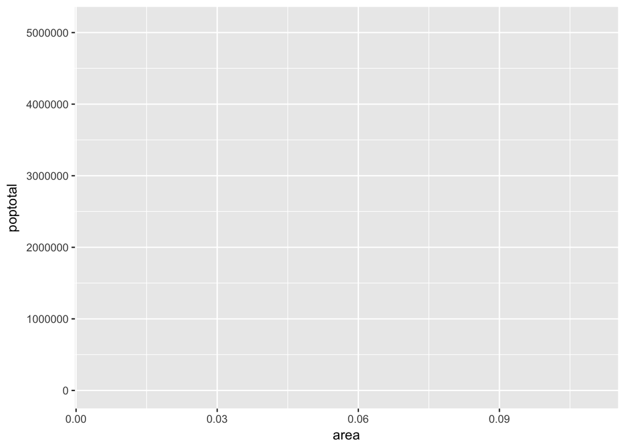

```r
# Initial Ggplot
ggplot(midwest, aes(x=area, y=poptotal))  # area and poptotal are columns in 'midwest'
```

There is no data points becuase I did not specify if I want a scatter plot or a line chart. Any information that is part of the source dataframe has to be specified inside the aes() function.

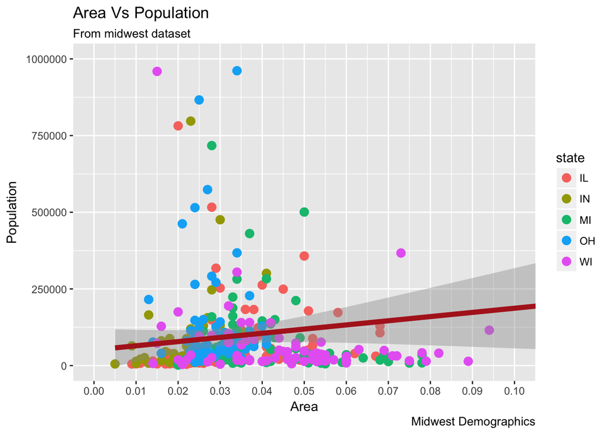

```r
library(ggplot2)

# Base plot
gg <- ggplot(midwest, aes(x=area, y=poptotal)) +
  geom_point(aes(col=state), size=3) +  # Set color to vary based on state categories.
  geom_smooth(method="lm", col="firebrick", size=2) +
  coord_cartesian(xlim=c(0, 0.1), ylim=c(0, 1000000)) +
  labs(title="Area Vs Population", subtitle="From midwest dataset", y="Population", x="Area", caption="Midwest Demographics")

# Change breaks
gg + scale_x_continuous(breaks=seq(0, 0.1, 0.01))
```

If you need to reverse the scale, use scale_x_reverse().

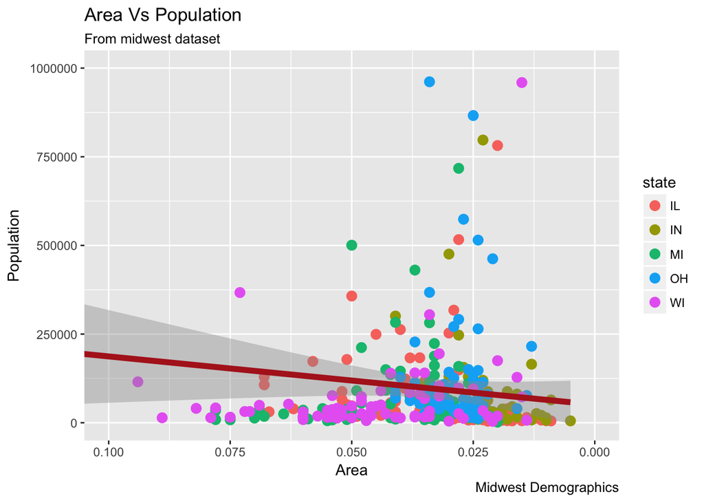

```r
gg <- ggplot(midwest, aes(x=area, y=poptotal)) +
  geom_point(aes(col=state), size=3) +  # Set color to vary based on state categories.
  geom_smooth(method="lm", col="firebrick", size=2) +
  coord_cartesian(xlim=c(0, 0.1), ylim=c(0, 1000000)) +
  labs(title="Area Vs Population", subtitle="From midwest dataset", y="Population", x="Area", caption="Midwest Demographics")

# Reverse X Axis Scale
gg + scale_x_reverse()
```

To write customized texts for axis labels, I have used 2 methods Method 1: Using sprintf(). (Have formatted it as % in below example) Method 2: Using a custom user defined function. (Formatted 1000’s to 1K scale) Use whichever method feels convenient.

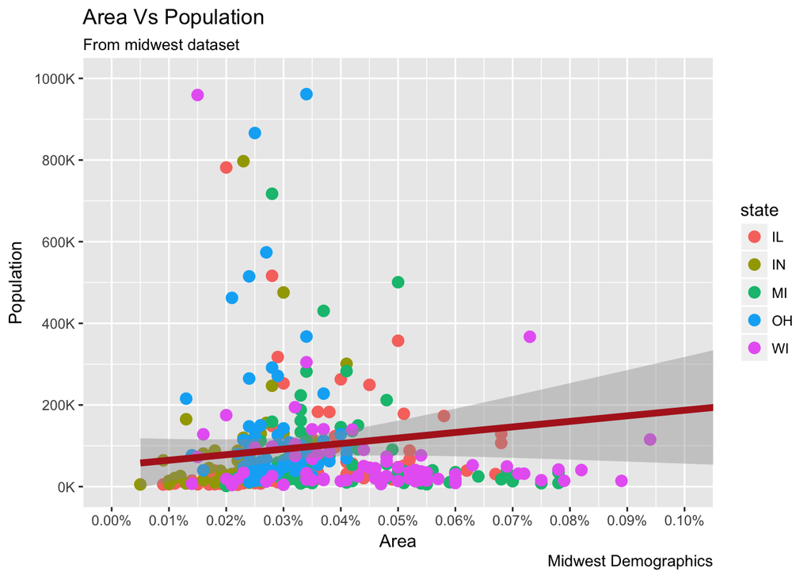

```r
# Base Plot
gg <- ggplot(midwest, aes(x=area, y=poptotal)) +
  geom_point(aes(col=state), size=3) +  # Set color to vary based on state categories.
  geom_smooth(method="lm", col="firebrick", size=2) +
  coord_cartesian(xlim=c(0, 0.1), ylim=c(0, 1000000)) +
  labs(title="Area Vs Population", subtitle="From midwest dataset", y="Population", x="Area", caption="Midwest Demographics")

# Change Axis Texts
gg + scale_x_continuous(breaks=seq(0, 0.1, 0.01), labels = sprintf("%1.2f%%", seq(0, 0.1, 0.01))) +
  scale_y_continuous(breaks=seq(0, 1000000, 200000), labels = function(x){paste0(x/1000, 'K')})
```

To Customize the entire theme in one shot using Pre-Built Themes, I have used 2 different methods. Method 1: Use the theme_set() to set the theme before drawing the ggplot. Note that this setting will affect all future plots. Method 2: Draw the ggplot and then add the overall theme setting (eg. theme_bw())

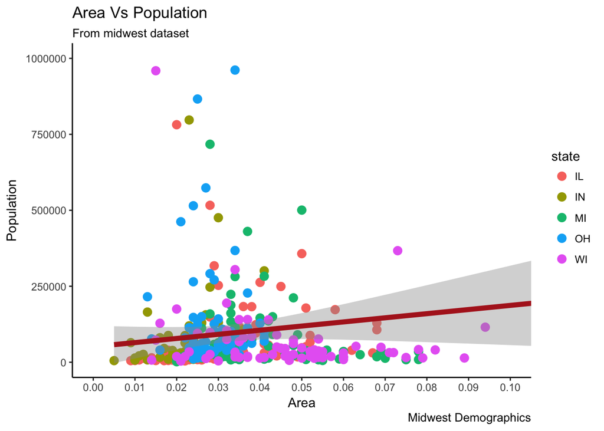

```r
# Base plot
gg <- ggplot(midwest, aes(x=area, y=poptotal)) +
  geom_point(aes(col=state), size=3) +  # Set color to vary based on state categories.
  geom_smooth(method="lm", col="firebrick", size=2) +
  coord_cartesian(xlim=c(0, 0.1), ylim=c(0, 1000000)) +
  labs(title="Area Vs Population", subtitle="From midwest dataset", y="Population", x="Area", caption="Midwest Demographics")

gg <- gg + scale_x_continuous(breaks=seq(0, 0.1, 0.01))

# method 1: Using theme_set()
theme_set(theme_classic())  # not run
gg
```

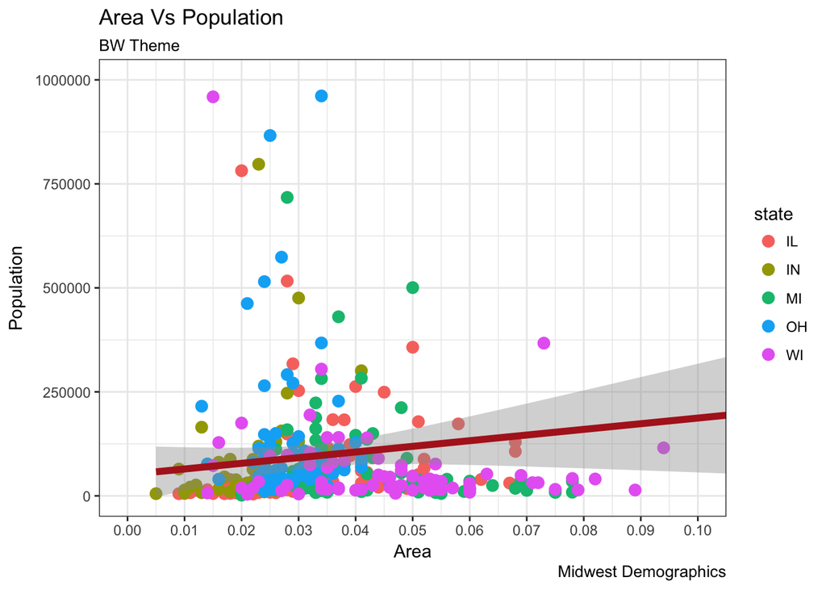

```r
# method 2: Adding theme Layer itself.
gg + theme_bw() + labs(subtitle="BW Theme")
```

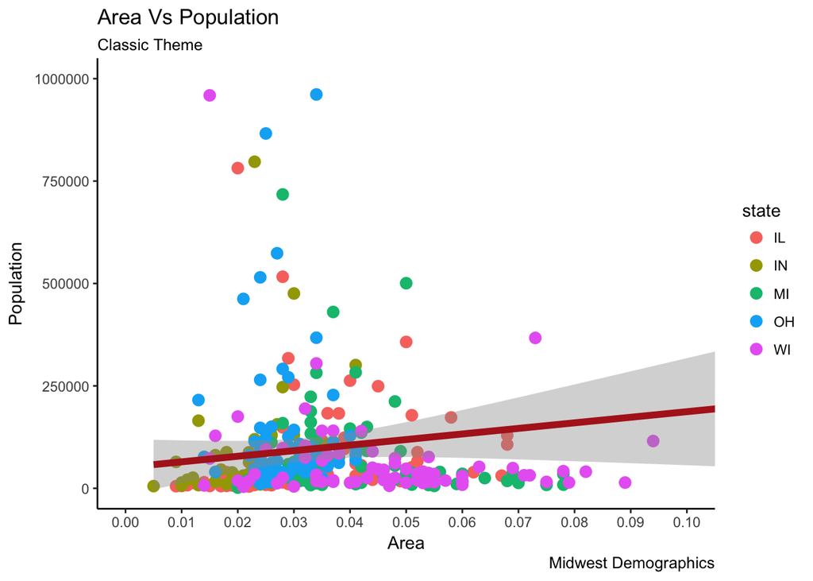

```r
gg + theme_classic() + labs(subtitle="Classic Theme")
```

More to come.. +Creating advanced visualizations : modifying theme components, manipulating legend, annotations, faceting and custom layouts.

# ***********************************************************************************************************